# Gender embeddings

## Preparing data

本次作業練習需要利用預訓練好的詞向量（word embedding），以下提供作業資料下載與使用的方法及說明。

- 如果你在自己電腦做作業：使用老師原本設計的方式
  - Download [the embedding](https://drive.google.com/file/d/1sfOjlQ0G_LXfvdBGFhIlG0UUj55GXhew/view?usp=sharing) `CBOW_iter15_2017-2018.bin` to your computer (Middle size, about 320 MB)
  - 請同學自行下載檔案並在本機環境執行作業檔案，如果碰到問題可以先就錯誤訊息到Google或其他平台上找答案，若真的無法解決再請同學到github問我們
- 如果你在colab上做作業：將資料下載到colab的環境

### 將資料下載到colab的環境

```python
# 直接執行這一行即可

!gdown --id '1OkR_STaIYXK6-BWY5RF1eikqysvML8-8' --output CBOW_iter15_2017-2018.bin

# 若上一個連結不能用，請用這一個備用的連結
# !gdown --id '1sfOjlQ0G_LXfvdBGFhIlG0UUj55GXhew' --output CBOW_iter15_2017-2018.bin
```

```
'gdown' 不是內部或外部命令、可執行的程式或批次檔。
```

## Loading data

```python
from gensim.models import KeyedVectors
w2v = KeyedVectors.load_word2vec_format("CBOW_iter15_2017-2018.bin", binary = True)
print(len(w2v.index2word))
```

```
265088
```

隨便找一個關鍵字來測試，可以知道每個詞被用300維的數字做代表。

```python
len(w2v['女性'])
```

```
300
```

# Design

## (TODO) 建立男性與女性代詞序列與職業的序列。

- 查找20~30個女性相關的代名詞並指給list `female`。建議用word-embedding的方法去找到在上述w2v中哪些字跟你現下所選的詞彙最為接近，然後依序把他們增加進來，然後再查找、再增加進來，過了幾個回合，大概就可以判斷自己想找的字詞達到飽和，若再加進來也會增加一些亂七八糟的東西。這樣的方法是幫助你把相關詞彙通通找進來的好方法，避免根據某些關鍵字來搜尋相關主題的文章時有所遺漏。
- `male`和`occupation`則分別增加男性的代名詞和職業。

```python
female = ["她", "妳", "女生", "女孩", "小姐", "妹仔", "老婆", "女兒", "女權", "人妻", "母親", "少婦", "媽媽", "腐女", "網美", "美女", "孕婦", "姪女", "少女", "碧池", "破麻", "熟女", "公主", "姊姊", "學姊", "學妹", "孫女", "外婆", "女人", "千金"]
male = ["他", "你", "男", "男生", "男人", "大哥", "學長", "學弟", "哥哥", "男性", "帥哥", "公豬", "姪子", "正太", "爸爸", "父親", "大叔", "少年", "青年", "紳士", "直男", "渣男", "8+9", "宅男", "兒子", "孫子", "老公", "外公", "義父", "偽娘"]
occupation = ['警察', '護理師', "護士", '老闆', '教練', '醫生', '工程師', '社畜', '教授', '老師', '廚師', '服務生', '陪侍', '招待', '網紅', 'youtuber', '經理', '董事長', '記者', '議員', '家教', '人資', '駕駛', '按摩師', '模特', '攝影師', '秘書', '導演', '演員', '軍人' ]
```

### Verify your vocabulary

You can use the following code to verify if your selected words exist in the wordEmbedding model. 要注意的是，這些詞彙是否出現在w2v的詞彙中，如果沒有出現在w2v的詞彙中時，後續的計算程式會因為無法找到該文字的key而報錯。

```python
print(len(male))
print(len(female))
print(len(occupation))
for word in female+male+occupation:
    if word not in w2v.vocab:
        print(word)
```

```
30
30
30
```

# (TODO) Comparing gender stereotype of occupations

- 你應該會有20~30個female words、20~30個male words、20~30個職業。
- 對於每個職業，去計算該職業和每個female words的similarity，求平均，假設為female_avg
- 對於每個職業，去計算該職業和每個male words的similarity，求平均，假設為male_avg
- 對於每個職業，印出該職業female_avg和male_avg哪個大，印的時候可以用ternary condition來判斷

  ```
  "<" if female_avg > male_avg elase ">"
  ```

- Expected results

  ```
  警察  male(0.21)  >   female(0.16)
  保母  male(0.19)  <   female(0.26)
  護士  male(0.30)  <   female(0.31)
  老闆  male(0.30)  >   female(0.28)
  ```

```python
for i in range(len(occupation)):
    occu = occupation[i]
    occu_male = 0
    occu_female = 0
    for j in range(len(male)):
        occu_male += w2v.similarity(occu, male[j])
        occu_female += w2v.similarity(occu, female[j])
    if occu_male > occu_female:
        print("%s\t%s(%f)\t >   %s(%f)" % (occu, "male", occu_male/len(male), "female", occu_female/len(female)))
        # print(occu, "male > female")
    else:
        print("%s\t%s(%f)\t <   %s(%f)" % (occu, "male", occu_male/len(male), "female", occu_female/len(female)))
        # print(occu, "male < female")
```

```
警察	male(0.177718)	 >   female(0.130538)
護理師	male(0.209865)	 <   female(0.271089)
護士	male(0.232510)	 <   female(0.286638)
老闆	male(0.244394)	 >   female(0.230406)
教練	male(0.191430)	 >   female(0.148885)
醫生	male(0.208402)	 <   female(0.229873)
工程師	male(0.105268)	 >   female(0.075233)
社畜	male(0.149824)	 >   female(0.108897)
教授	male(0.080397)	 >   female(0.040587)
老師	male(0.264592)	 <   female(0.273082)
廚師	male(0.187439)	 >   female(0.171131)
服務生	male(0.186940)	 <   female(0.208918)
陪侍	male(0.129458)	 <   female(0.142097)
招待	male(-0.007217)	 <   female(0.008232)
網紅	male(0.203914)	 <   female(0.229775)
youtuber	male(0.184538)	 >   female(0.171127)
經理	male(0.035321)	 <   female(0.038152)
董事長	male(-0.031222)	 >   female(-0.044780)
記者	male(0.018000)	 <   female(0.022452)
議員	male(0.079535)	 <   female(0.089215)
家教	male(0.157635)	 >   female(0.154098)
人資	male(0.043314)	 >   female(0.036561)
駕駛	male(0.075963)	 >   female(0.037569)
按摩師	male(0.180038)	 <   female(0.199430)
模特	male(0.183280)	 <   female(0.218215)
攝影師	male(0.205240)	 <   female(0.234406)
秘書	male(0.051081)	 <   female(0.067330)
導演	male(0.226122)	 >   female(0.208067)
演員	male(0.246649)	 >   female(0.223976)
軍人	male(0.154149)	 >   female(0.104809)
```

# (TODO) Visualization with PCA

照word embedding的教學抽取出所有上述職業和性別化稱謂的詞彙詞嵌入向量（每個字詞被表示為300維的向量），以PCA進行降維後，用Bokeh做視覺化，預期視覺化結果如下：

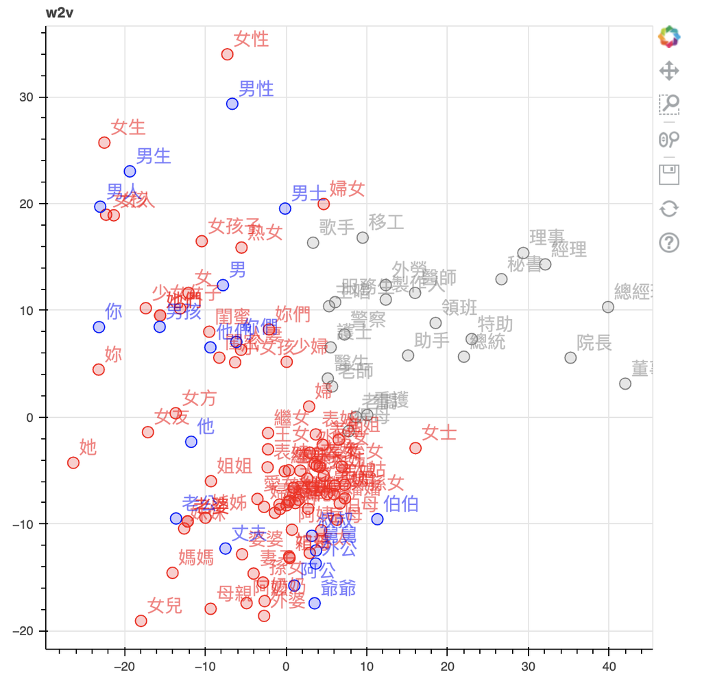

## Dimension reduction by PCA

```python
# !pip install sklearn
from sklearn.decomposition import PCA
pca = PCA(n_components=2)

spec = []
label = []
for word in female+male+occupation:
    spec.append(w2v[word])
    label.append(word)

points = pca.fit_transform(spec)
print(len(points))
print(points[:5])
```

```
90
[[ 31.42529955  -6.85283281]
 [ 21.83145432 -15.30915514]
 [  3.85475213 -25.41601891]
 [  8.91357033 -22.52307511]
 [ -0.0386187   14.45322461]]
```

## Constructing pandas dataframe for visualization

```python
import pandas as pd
df = pd.DataFrame(points, columns =['X', 'Y'])
df['labels'] = label
df
```

|  | X | Y | labels |
| --- | --- | --- | --- |
| 0 | 31.425300 | -6.852833 | 她 |
| 1 | 21.831454 | -15.309155 | 妳 |
| 2 | 3.854752 | -25.416019 | 女生 |
| 3 | 8.913570 | -22.523075 | 女孩 |
| 4 | -0.038619 | 14.453225 | 小姐 |
| ... | ... | ... | ... |
| 85 | -9.668558 | -0.936750 | 攝影師 |
| 86 | -17.580361 | 17.958205 | 秘書 |
| 87 | -1.522310 | -0.765588 | 導演 |
| 88 | -7.918348 | -9.775904 | 演員 |
| 89 | -7.014313 | 4.750691 | 軍人 |

90 rows × 3 columns

## Visualization by bokeh

```python
# !pip install bokeh
# !pip install jupyter_bokeh
from bokeh.models import ColumnDataSource, Label, LabelSet, Range1d
from bokeh.plotting import figure, output_file, show
from bokeh.io import output_notebook
output_notebook()
```

```python
p = figure(title = "w2v")
p.circle(df["X"], df["Y"], fill_alpha=0.2, size=10)
labels_female = LabelSet(x='X', y='Y', text='labels',
                  x_offset=5, y_offset=5,
                  source=ColumnDataSource(df[:30]), render_mode='canvas', text_color = "red")
labels_male = LabelSet(x='X', y='Y', text='labels',
                  x_offset=5, y_offset=5,
                  source=ColumnDataSource(df[30:60]), render_mode='canvas', text_color = "blue")
labels_occu = LabelSet(x='X', y='Y', text='labels',
                  x_offset=5, y_offset=5,
                  source=ColumnDataSource(df[60:90]), render_mode='canvas')
p.add_layout(labels_female)
p.add_layout(labels_male)
p.add_layout(labels_occu)
show(p)
```

[interactive chart not shown]

# Visualization with t-SNE

## Dimension reduction by t-SNE

```python
from sklearn.manifold import TSNE
tsne = TSNE(n_components=2, random_state=0)

spec2 = []
label2 = []
for word in female+male+occupation:
    spec2.append(w2v[word])
    label2.append(word)

points2 = tsne.fit_transform(spec2)
print(len(points2))
print(points2[:5])
```

```
90
[[-74.22438   -18.415049 ]
 [-80.514046    3.359263 ]
 [ 18.144596  -66.03131  ]
 [  6.9622664 -67.18622  ]
 [-52.04818     7.8366666]]
```

## Visualization

```python
df2 = pd.DataFrame(points2, columns =['X', 'Y'])
df2['labels'] = label
df2
```

|  | X | Y | labels |
| --- | --- | --- | --- |
| 0 | -74.224380 | -18.415049 | 她 |
| 1 | -80.514046 | 3.359263 | 妳 |
| 2 | 18.144596 | -66.031311 | 女生 |
| 3 | 6.962266 | -67.186218 | 女孩 |
| 4 | -52.048180 | 7.836667 | 小姐 |
| ... | ... | ... | ... |
| 85 | 56.569324 | -18.315742 | 攝影師 |
| 86 | 36.427258 | 41.071865 | 秘書 |
| 87 | -58.858017 | 47.940845 | 導演 |
| 88 | 30.857677 | -43.552715 | 演員 |
| 89 | -0.589773 | -40.888088 | 軍人 |

90 rows × 3 columns

```python
p = figure(title = "w2v")
p.circle(df2["X"], df2["Y"], fill_alpha=0.2, size=10)
labels_female = LabelSet(x='X', y='Y', text='labels',
                  x_offset=5, y_offset=5,
                  source=ColumnDataSource(df2[:30]), render_mode='canvas', text_color = "red")
labels_male = LabelSet(x='X', y='Y', text='labels',
                  x_offset=5, y_offset=5,
                  source=ColumnDataSource(df2[30:60]), render_mode='canvas', text_color = "blue")
labels_occu = LabelSet(x='X', y='Y', text='labels',
                  x_offset=5, y_offset=5,
                  source=ColumnDataSource(df2[60:90]), render_mode='canvas')
p.add_layout(labels_female)
p.add_layout(labels_male)
p.add_layout(labels_occu)
show(p)
```

[interactive chart not shown]